# Red wine quality by Abdullah Tarek

## Introduction:

> This Dataset contains 1599 red wines and 11 variables for each wine and thier corresponding qualty scores. The aim of this project is to find out wich attributes is most responsible for the quality of the wine, and to make a model that can predict the quality of the wine given its attributes.

## Data wrangling

> It is usefull to check for null values and deal with them in our dataset to avoid throwing off our analysis. by running the summary command we can check if there are any null values in all of the columns. As you can see bellow there are non. We are ready for next steps.

```r
head(pf)
```

```
##   fixed.acidity volatile.acidity citric.acid residual.sugar chlorides
## 1           7.4             0.70        0.00            1.9     0.076
## 2           7.8             0.88        0.00            2.6     0.098
## 3           7.8             0.76        0.04            2.3     0.092
## 4          11.2             0.28        0.56            1.9     0.075
## 5           7.4             0.70        0.00            1.9     0.076
## 6           7.4             0.66        0.00            1.8     0.075
##   free.sulfur.dioxide total.sulfur.dioxide density   pH sulphates alcohol
## 1                  11                   34  0.9978 3.51      0.56     9.4
## 2                  25                   67  0.9968 3.20      0.68     9.8
## 3                  15                   54  0.9970 3.26      0.65     9.8
## 4                  17                   60  0.9980 3.16      0.58     9.8
## 5                  11                   34  0.9978 3.51      0.56     9.4
## 6                  13                   40  0.9978 3.51      0.56     9.4
##   quality
## 1       5
## 2       5
## 3       5
## 4       6
## 5       5
## 6       5
```

```r
summary(pf)
```

```
##  fixed.acidity   volatile.acidity  citric.acid    residual.sugar
##  Min.   : 4.60   Min.   :0.1200   Min.   :0.000   Min.   : 0.900
##  1st Qu.: 7.10   1st Qu.:0.3900   1st Qu.:0.090   1st Qu.: 1.900
##  Median : 7.90   Median :0.5200   Median :0.260   Median : 2.200
##  Mean   : 8.32   Mean   :0.5278   Mean   :0.271   Mean   : 2.539
##  3rd Qu.: 9.20   3rd Qu.:0.6400   3rd Qu.:0.420   3rd Qu.: 2.600
##  Max.   :15.90   Max.   :1.5800   Max.   :1.000   Max.   :15.500
##    chlorides       free.sulfur.dioxide total.sulfur.dioxide
##  Min.   :0.01200   Min.   : 1.00       Min.   :  6.00
##  1st Qu.:0.07000   1st Qu.: 7.00       1st Qu.: 22.00
##  Median :0.07900   Median :14.00       Median : 38.00
##  Mean   :0.08747   Mean   :15.87       Mean   : 46.47
##  3rd Qu.:0.09000   3rd Qu.:21.00       3rd Qu.: 62.00
##  Max.   :0.61100   Max.   :72.00       Max.   :289.00
##     density             pH          sulphates         alcohol      quality
##  Min.   :0.9901   Min.   :2.740   Min.   :0.3300   Min.   : 8.40   3: 10
##  1st Qu.:0.9956   1st Qu.:3.210   1st Qu.:0.5500   1st Qu.: 9.50   4: 53
##  Median :0.9968   Median :3.310   Median :0.6200   Median :10.20   5:681
##  Mean   :0.9967   Mean   :3.311   Mean   :0.6581   Mean   :10.42   6:638
##  3rd Qu.:0.9978   3rd Qu.:3.400   3rd Qu.:0.7300   3rd Qu.:11.10   7:199
##  Max.   :1.0037   Max.   :4.010   Max.   :2.0000   Max.   :14.90   8: 18
```

## Univariate Plots Section

> **Tip**: In this section, you should perform some preliminary exploration of your dataset. Run some summaries of the data and create univariate plots to understand the structure of the individual variables in your dataset. Don’t forget to add a comment after each plot or closely-related group of plots! There should be multiple code chunks and text sections; the first one below is just to help you get started.

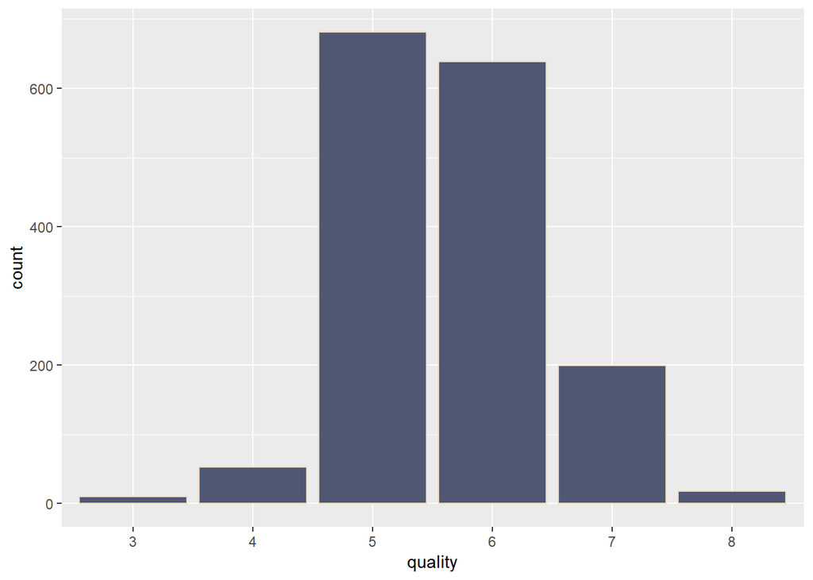

```
##
##   3   4   5   6   7   8
##  10  53 681 638 199  18
```

> Most of the dataset are of quality 5 or 6. This raises questions on how the dataset was collected. Maybe it was collected from average bars only where average wines are the main demand and expensive or very cheap wines are not ordered as much. This will make it hard for the model to get good scores at detecting wine quality scores.

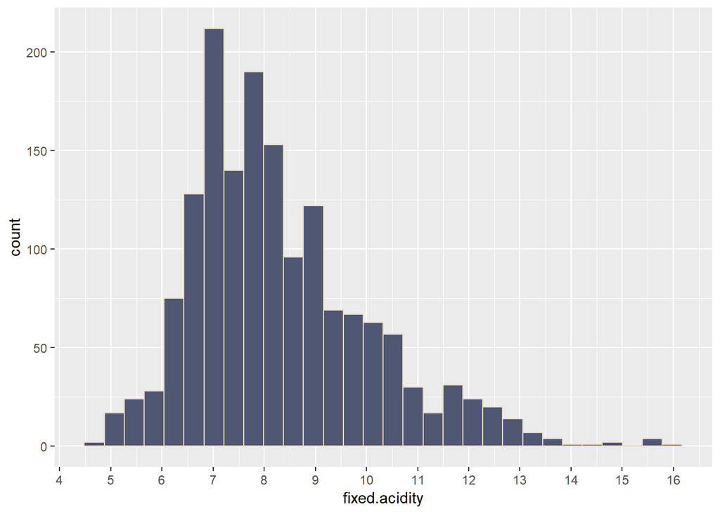

```
##    Min. 1st Qu.  Median    Mean 3rd Qu.    Max.
##    4.60    7.10    7.90    8.32    9.20   15.90
```

Fixed acidty is right skewed with some outliers that are on the far right. We can subset the dataset so that it does not include the outliers.

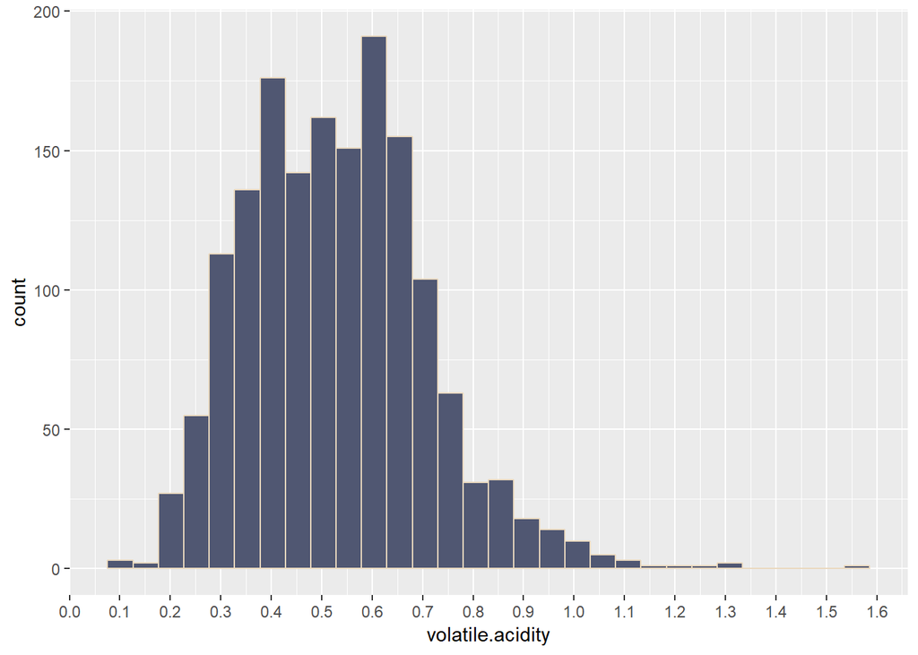

```
##    Min. 1st Qu.  Median    Mean 3rd Qu.    Max.
##  0.1200  0.3900  0.5200  0.5278  0.6400  1.5800
```

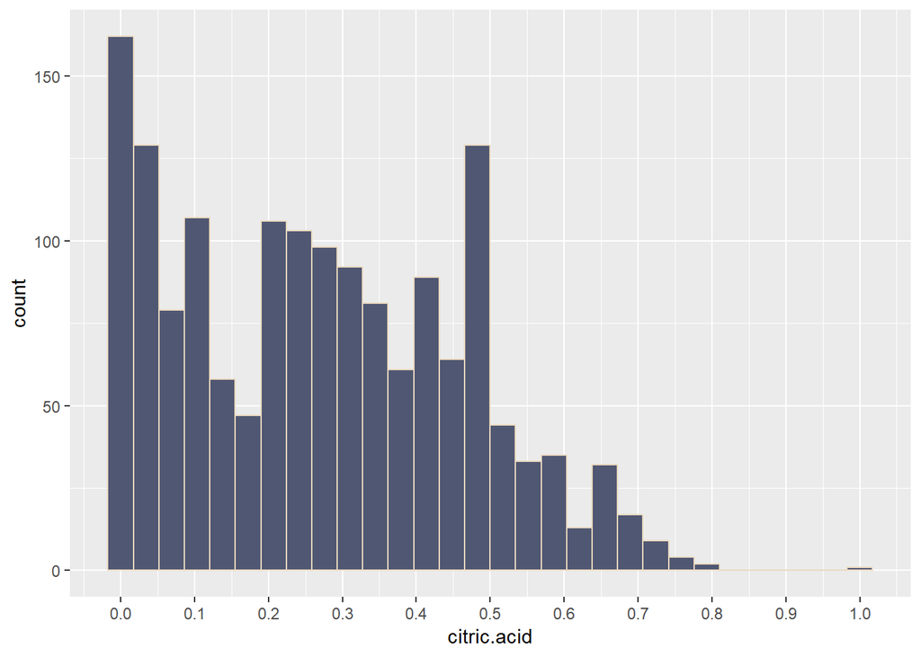

```
##    Min. 1st Qu.  Median    Mean 3rd Qu.    Max.
##  0.0000  0.0900  0.2600  0.2714  0.4200  1.0000
```

The citric acid column has a weird distribution. it is not skewed, bimodal nor normal. This column has outliers on the right.

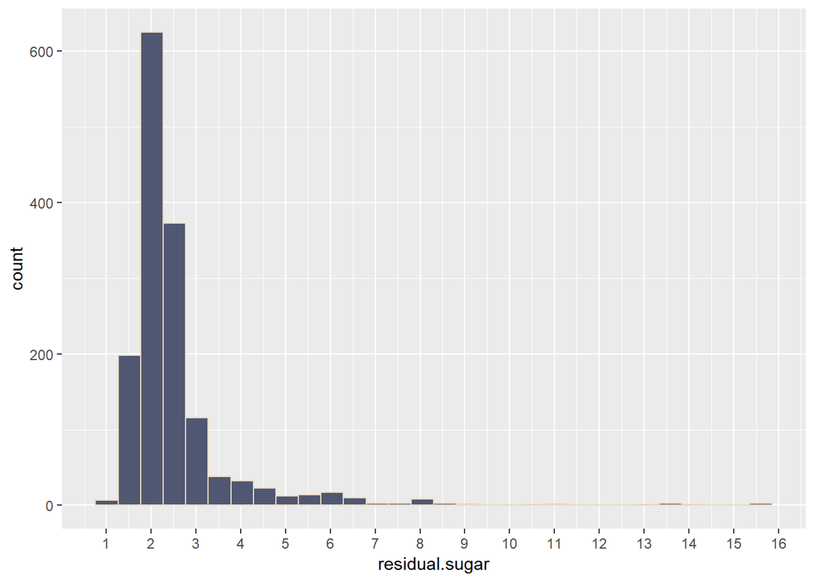

```
##    Min. 1st Qu.  Median    Mean 3rd Qu.    Max.
##   0.900   1.900   2.200   2.541   2.600  15.500
```

The residual.ugar column is also right skewed with outliers on the right of the graph.

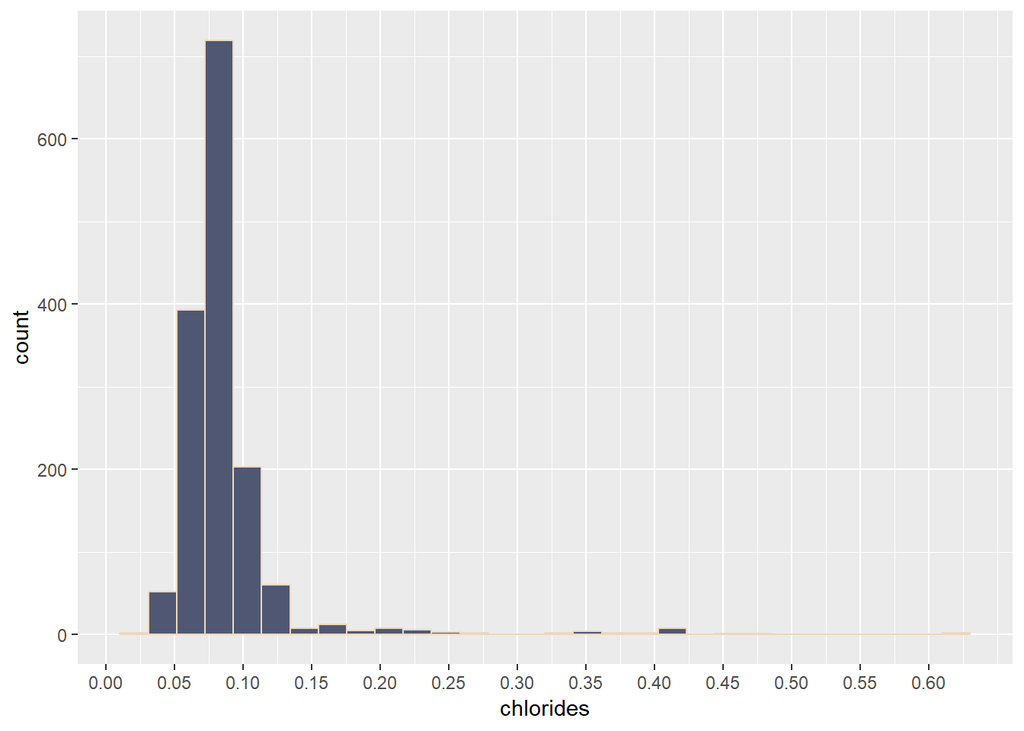

```
##    Min. 1st Qu.  Median    Mean 3rd Qu.    Max.
## 0.01200 0.07000 0.07900 0.08761 0.09000 0.61100
```

The chlorides column is also right skewed with some outliers.

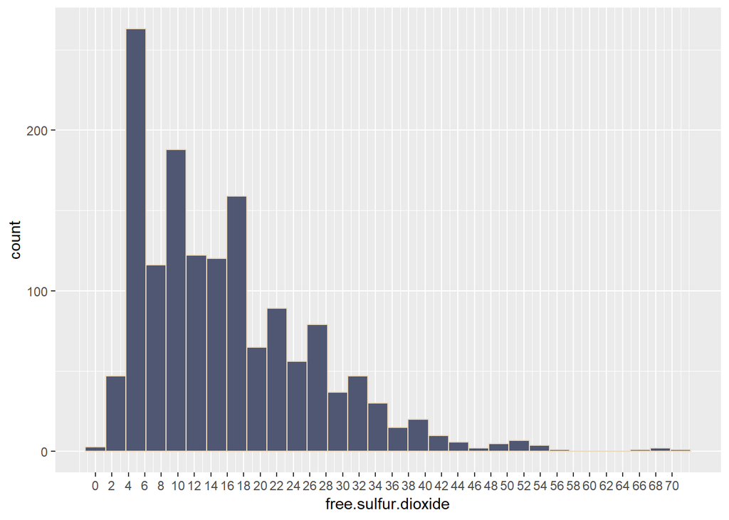

```
##    Min. 1st Qu.  Median    Mean 3rd Qu.    Max.
##    1.00    8.00   14.00   15.94   21.00   72.00
```

free.sulfer.dioxide is right skewed with outliers on the right.

[figure not shown]

```
##    Min. 1st Qu.  Median    Mean 3rd Qu.    Max.
##    6.00   22.00   38.00   46.23   62.00  289.00
```

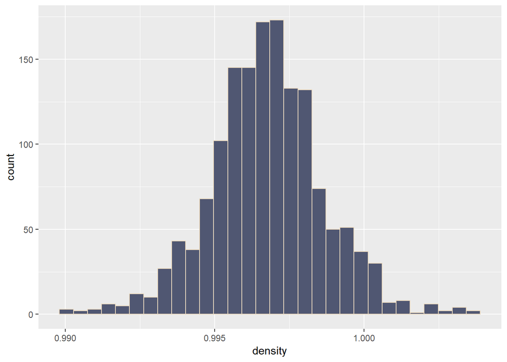

```
##    Min. 1st Qu.  Median    Mean 3rd Qu.    Max.
##  0.9901  0.9956  0.9968  0.9968  0.9978  1.0037
```

The density columns is normally distributed with mean 0.997.

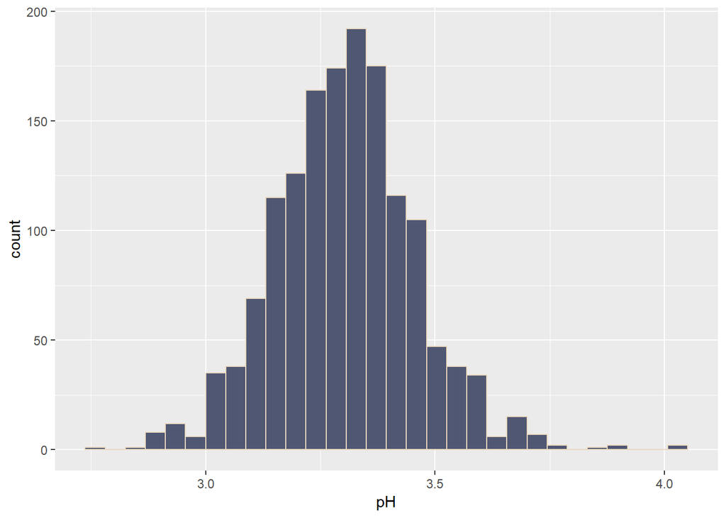

```
##    Min. 1st Qu.  Median    Mean 3rd Qu.    Max.
##   2.740   3.200   3.300   3.305   3.400   4.010
```

The ph column is normally ditributed with a mean of 3.3

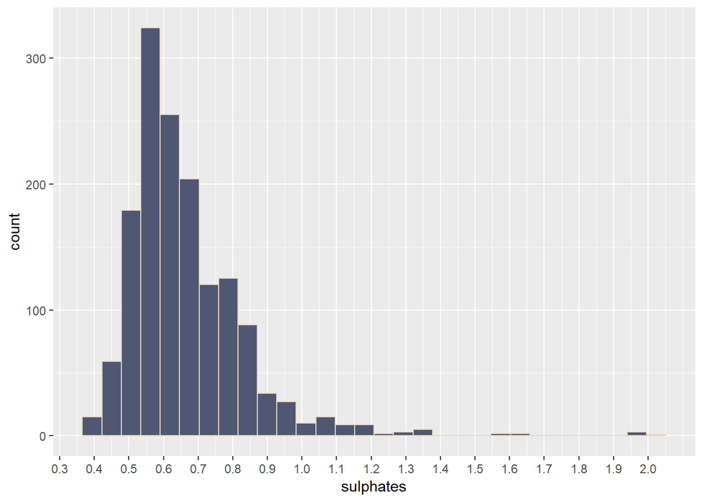

```
##    Min. 1st Qu.  Median    Mean 3rd Qu.    Max.
##  0.3700  0.5600  0.6300  0.6651  0.7400  2.0000
```

sulphates column is right skewed with some outliers on the right.

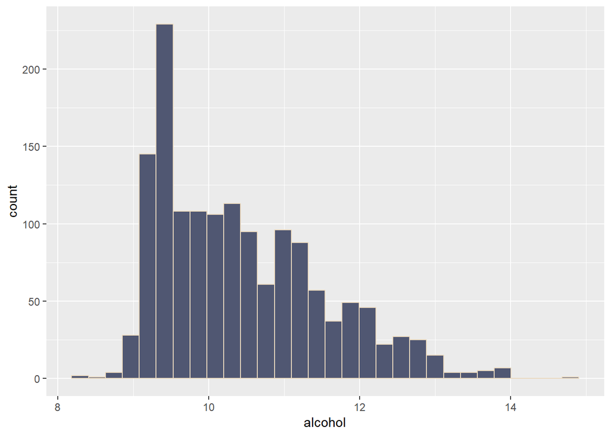

```
##    Min. 1st Qu.  Median    Mean 3rd Qu.    Max.
##    8.40    9.50   10.20   10.43   11.10   14.90
```

The alcohol column is right skewed.

### Univariate Analysis summary

1. most of the wines in the dataset have a quality of 5 or 6. This might effect the regression model. Also This raises questions about how the data was collected.
2. Alot of the columns in the dataset were right skewed with some outliers. Those outliers can be dealt with by removal.
3. There are some normally disributed columns like PH, and denity those might be usefull for any inferential statistics.

## Bivariate Analysis

First we will see the relationship between all columns and the quality column. since this is a qualitative, quantitative comparison, it makes sense to use box-plots.

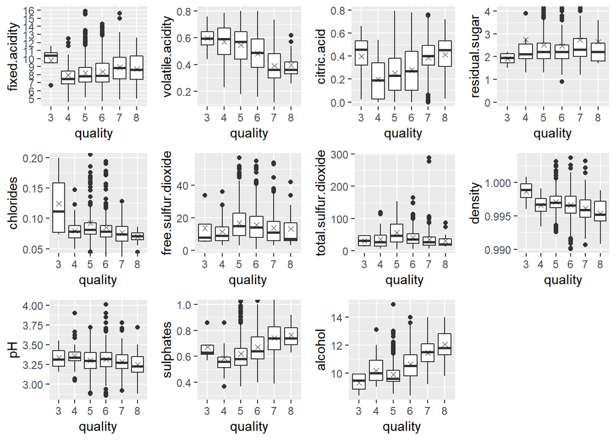

### Summary of the box-plots:

```
##                      fixed.acidity volatile.acidity citric.acid
## fixed.acidity                 1.00            -0.27        0.68
## volatile.acidity             -0.27             1.00       -0.57
## citric.acid                   0.68            -0.57        1.00
## residual.sugar                0.13             0.01        0.16
## chlorides                     0.10             0.08        0.20
## free.sulfur.dioxide          -0.16             0.01       -0.08
## total.sulfur.dioxide         -0.13             0.10        0.01
## density                       0.67             0.06        0.37
## pH                           -0.69             0.20       -0.54
## sulphates                     0.20            -0.25        0.31
## alcohol                      -0.05            -0.25        0.12
## quality                       0.12            -0.36        0.21
##                      residual.sugar chlorides free.sulfur.dioxide
## fixed.acidity                  0.13      0.10               -0.16
## volatile.acidity               0.01      0.08                0.01
## citric.acid                    0.16      0.20               -0.08
## residual.sugar                 1.00      0.05                0.14
## chlorides                      0.05      1.00               -0.01
## free.sulfur.dioxide            0.14     -0.01                1.00
## total.sulfur.dioxide           0.19      0.04                0.66
## density                        0.35      0.20               -0.04
## pH                            -0.10     -0.25                0.09
## sulphates                      0.03      0.35                0.04
## alcohol                        0.05     -0.22               -0.07
## quality                        0.03     -0.11               -0.06
##                      total.sulfur.dioxide density    pH sulphates alcohol
## fixed.acidity                       -0.13    0.67 -0.69      0.20   -0.05
## volatile.acidity                     0.10    0.06  0.20     -0.25   -0.25
## citric.acid                          0.01    0.37 -0.54      0.31    0.12
## residual.sugar                       0.19    0.35 -0.10      0.03    0.05
## chlorides                            0.04    0.20 -0.25      0.35   -0.22
## free.sulfur.dioxide                  0.66   -0.04  0.09      0.04   -0.07
## total.sulfur.dioxide                 1.00    0.05 -0.04     -0.02   -0.21
## density                              0.05    1.00 -0.34      0.16   -0.50
## pH                                  -0.04   -0.34  1.00     -0.13    0.18
## sulphates                           -0.02    0.16 -0.13      1.00    0.13
## alcohol                             -0.21   -0.50  0.18      0.13    1.00
## quality                             -0.22   -0.18 -0.05      0.28    0.50
##                      quality
## fixed.acidity           0.12
## volatile.acidity       -0.36
## citric.acid             0.21
## residual.sugar          0.03
## chlorides              -0.11
## free.sulfur.dioxide    -0.06
## total.sulfur.dioxide   -0.22
## density                -0.18
## pH                     -0.05
## sulphates               0.28
## alcohol                 0.50
## quality                 1.00
```

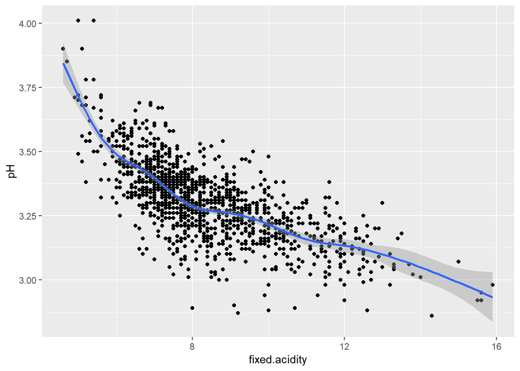

```r
ggplot(aes(x=fixed.acidity , y=pH),data=pf)+
  geom_point()+
  geom_smooth()
```

this plot shows the negative correlation between pH and fixed acidity.

# Multivariate Plots Section

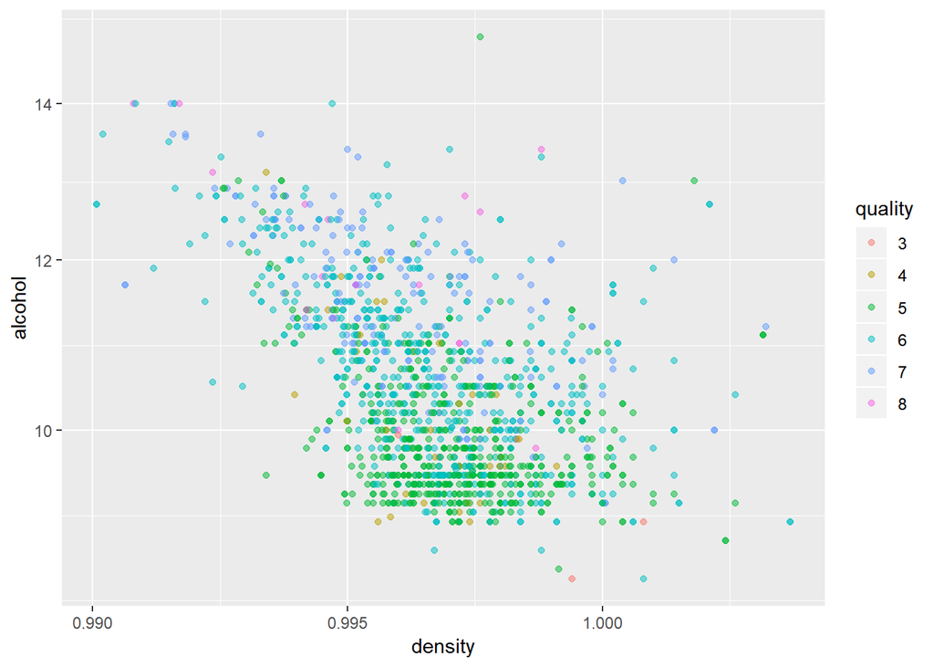

This plot shows that of wines with quality 5 have alcohol levels lower than 10 and most of the wines woth qualitylevel 6 are above 10.

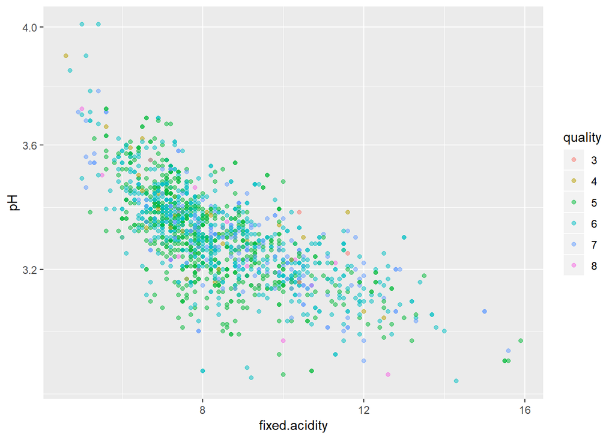

Here The plot doesn’t show any noticeable differences in the qualites.

### Logistic regression model

Acordiing to the analysis I will make a logistic regression model with the columns that have an effect on quality.

```
## Logistic Regression Model
##
##  lrm(formula = I(quality) ~ I(alcohol) + volatile.acidity + sulphates +
##      citric.acid, data = pf)
##
##
##  Frequencies of Responses
##
##    3   4   5   6   7   8
##    4  35 621 612 194  17
##
##                        Model Likelihood     Discrimination    Rank Discrim.
##                           Ratio Test           Indexes           Indexes
##  Obs          1483    LR chi2     590.13    R2       0.365    C       0.786
##  max |deriv| 3e-10    d.f.             4    g        1.576    Dxy     0.571
##                       Pr(> chi2) <0.0001    gr       4.836    gamma   0.572
##                                             gp       0.297    tau-a   0.364
##                                             Brier    0.181
##
##                   Coef     S.E.   Wald Z Pr(>|Z|)
##  y>=4              -3.1515 0.8557  -3.68 0.0002
##  y>=5              -5.4715 0.7131  -7.67 <0.0001
##  y>=6              -9.3850 0.7126 -13.17 <0.0001
##  y>=7             -12.1902 0.7517 -16.22 <0.0001
##  y>=8             -15.2393 0.8093 -18.83 <0.0001
##  alcohol            0.9448 0.0565  16.72 <0.0001
##  volatile.acidity  -3.7470 0.4630  -8.09 <0.0001
##  sulphates          2.9615 0.3761   7.87 <0.0001
##  citric.acid       -0.5309 0.3440  -1.54 0.1228
##
```

# Multivariate Analysis

# Final Plots and Summary

> **Tip**: You’ve done a lot of exploration and have built up an understanding of the structure of and relationships between the variables in your dataset. Here, you will select three plots from all of your previous exploration to present here as a summary of some of your most interesting findings. Make sure that you have refined your selected plots for good titling, axis labels (with units), and good aesthetic choices (e.g. color, transparency). After each plot, make sure you justify why you chose each plot by describing what it shows.

### Plot One

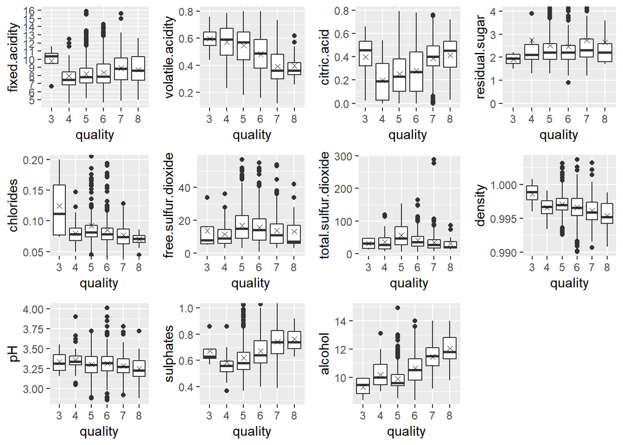

### Description One

This plot was crutial to see realtionships between the quality and each attribute. we noticed that volatile.acidity, citric acid,sulphates, alcohol,and chlorides are correlated with quality.

### Plot Two

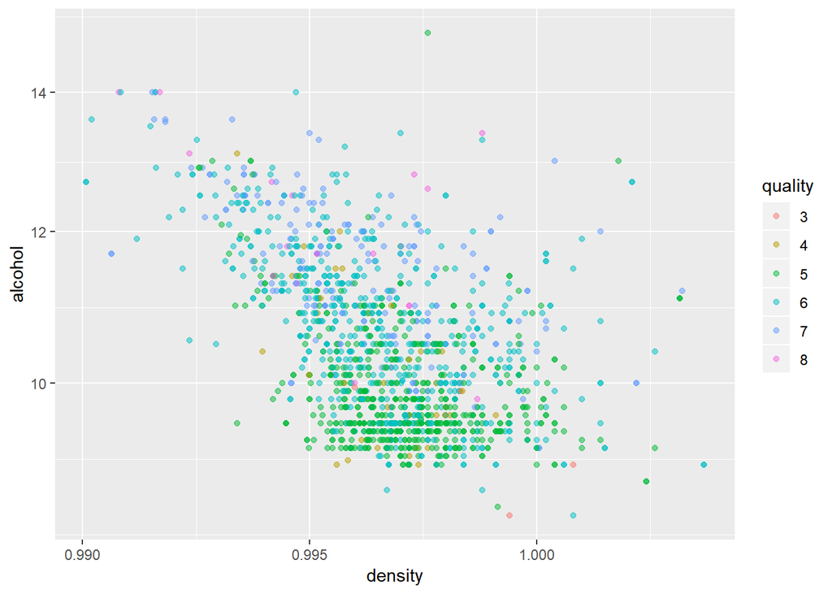

### Description Two

This Plot helped us deffrentiate between two qualities that are most abundant in the dataset. It showed us that most of the wines with quality of 5 have alcohol levels bellow 10 and most of the wines with quality of 6 had an alcohol level above 10.

# Reflection

Although there were some variables with good correlation with quality we were not able to make a good model, This is partailly because of the nature of the data-set. Most of the qualities of wine were either 5 or 6 and all others had a very small count in comparison to 5 or 6.